# R Package: canadianmaps

### Author: Joëlle Cayen

joelle.cayen@phac-aspc.gc.ca

## Background

This package was developed to address the gap in Canadian mapping in R. Statistics Canada releases map shape files for Provincial and Forward Sortation Area (FSA) data (among many others), however these data are difficult to manipulate and create maps with in R. The `canadianmaps` package contains three condensed datasets (using the original StatCan data) designed to map Canadian Provincial, FSA, and Regional data using regular R plotting methods (ggplot2), along with several functions to make Canadian mapping easy (i.e. transform longitude and latitude points to the corresponding coordinates systems, add labels to the centroids of map shapes, etc.).

### Existing resources

#### Transforming StatCan shapefiles

https://teng.pub/technical/2020/1/7/drawing-canada-maps-in-r  
https://blog.exploratory.io/making-maps-for-canadas-provisions-and-census-divisions-in-r-c189b88ccd8a

#### mapcan package

https://cran.r-project.org/web/packages/mapcan/vignettes/choropleth_maps_vignette.html

#### Limitations with existing methods

- Difficult and time consuming to transform the StatCan shapefiles using R
- Needed FSA (Forward Sortation Area) shapefile (not currently included in mapcan package)
- Needed to overlay points (longitude/latitude) (not currently a feature in mapcan)
- Needed to add labels to the center of each province/region (not currently a feature in mapcan)

## Installing and loading the package

This package is publicly available to download on GitHub as well as on CRAN. To install and load you can run the following lines in the console:

```r
devtools::install_github("joellecayen/canadianmaps")
#or
install.packages("canadianmaps")

library(canadianmaps)
```

This package currently comes with three datasets:

- PROV (Provincial map file)
- FSA (Forward Sortation Area map file)
- REG (Regional map file)

The `PROV` dataset has 13 rows, one for each Province/Territory. It contains columns providing users with different options for Province/Territory names; X and Y variable columns, which represent the centroid of each Province/Territory shape (used for adding labels); and the geometry column, which contains nested lists making up the complex geometry shapes for each Province/Territory.

| PRUID | PT | region | PRNAME | PRENAME | PRFNAME | PREABBR | PRFABBR | rmapshaperid | X | Y | geometry |
| --- | --- | --- | --- | --- | --- | --- | --- | --- | --- | --- | --- |
| 59 | BC | Western | British Columbia / Colombie-Britannique | British Columbia | Colombie-Britannique | B.C. | C.-B. | 0 | -1960160.6 | 7742755 | list(list(c(-12… |
| 24 | QC | Central | Quebec / Québec | Quebec | Québec | Que. | Qc | 1 | 1263508.8 | 7102332 | list(list(c(-58… |
| 62 | NU | Northern | Nunavut | Nunavut | Nunavut | Nvt. | Nt | 2 | -279322.0 | 8464103 | list(list(c(-90… |
| 11 | PE | Eastern | Prince Edward Island / Île-du-Prince-Édouard | Prince Edward Island | Île-du-Prince-Édouard | P.E.I. | Î.-P.-É. | 3 | 2095651.7 | 6773952 | list(list(c(-63… |
| 47 | SK | Western | Saskatchewan | Saskatchewan | Saskatchewan | Sask. | Sask. | 4 | -907500.9 | 7301246 | list(list(c(-10… |
| 60 | YT | Northern | Yukon | Yukon | Yukon | Y.T. | Yn | 5 | -1913592.4 | 9021174 | list(list(c(-13… |

## Overview of available functions

- `theme_map()`
- `geom_prov()`
- `greom_reg()`
- `geom_fsa()`
- `label_prov()`
- `label_reg()`
- `text_prov()`
- `scale_fill_map()`
- `scale_color_map()`
- `crs_coord()`
- `coord_transform()`

The `geom_prov()` function loads and maps the Provincial dataset, this is to be used in combination with `ggplot2`. `crs_coord()` contains the `crs` string which is required for mapping (this is all done behind scenes so you will not need to add anything in this function). The `theme_map()` function gives ggplot a blank canvas to map on. The `scale_fill_map()` and `scale_color_map()` functions have several custom color palettes which can be used for mapping and filling/coloring qualitative data (works with other types of graphs in `ggplot2` as well).

### Color palettes

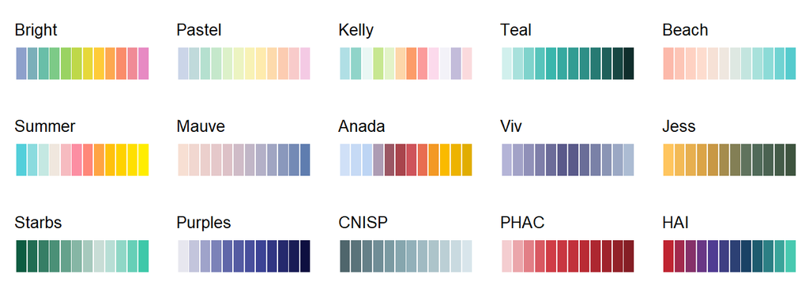

## Mapping Provincial data

### Creating the base shape layer

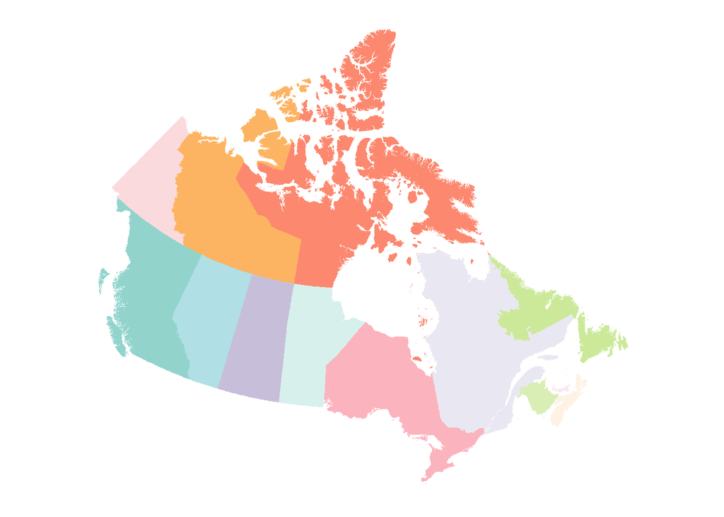

```r
library(ggplot2)
library(canadianmaps)

ggplot() +
          geom_prov() + # load and map provincial data
          crs_coord() + # this is required for mapping (stores the coordinate system)
          scale_fill_map("Kelly", 13) + # palette Kelly and assigning 13 colors
          guides(fill = "none") + # this removes the color legend
          theme_map() # sets backgroud to blank canvas
```

### Adding text

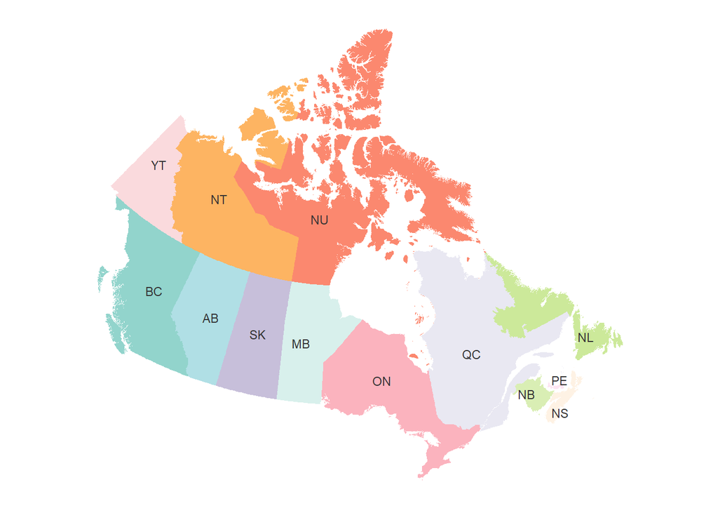

```r
ggplot() +
   geom_prov() + # load and map provincial data
   crs_coord() + # this is required for mapping (stores the coordinate system)
   scale_fill_map("Kelly", 13) + # palette Kelly and assigning 13 colors
   guides(fill = "none") + # this removes the color legend
   theme_map() + # sets backgroud to blank canvas
   text_prov() # default is PT
```

### Adding labels and outline

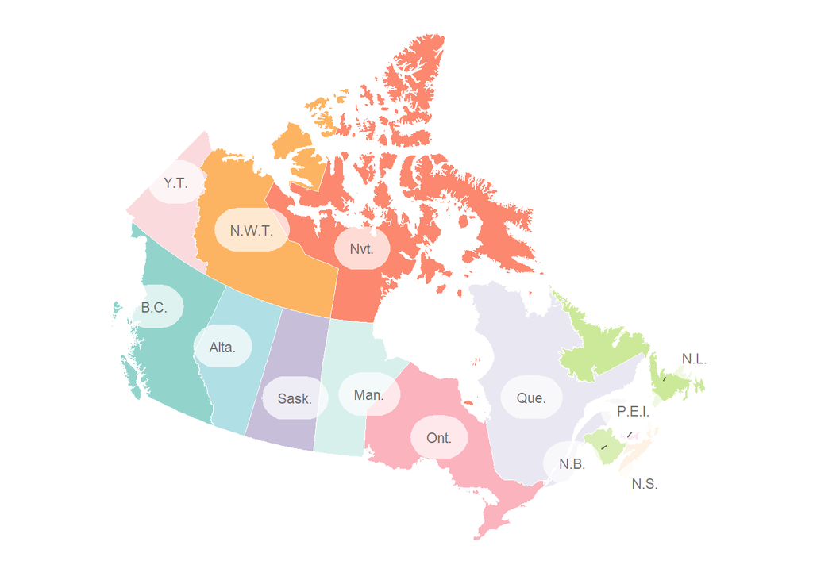

```r
ggplot() +
   geom_prov(colour="white", size=0.2) + # Specifying a colour and size will add an outline to all the province shapes (default is NA)
   crs_coord() +
   scale_fill_map("Kelly", 13) +
   guides(fill = "none") +
   theme_map() +
   label_prov(label="PREABBR") # I chose the column with the English abbreviations
```

## Adding your data to the shapefile

Here’s an example dataset called `data` that we want to map. It has 13 rows (one for each Province/Territory) and has three variables: prov, values, and perc.

```
##    prov values perc
## 1    BC      2   4%
## 2    QC      4   9%
## 3    NU      1   2%
## 4    PE      3   7%
## 5    SK      6  13%
## 6    YT      0   0%
## 7    MB      3   7%
## 8    ON      8  17%
## 9    NB      9  20%
## 10   NT      2   4%
## 11   AB      1   2%
## 12   NL      0   0%
## 13   NS      7  15%
```

We’re going to take our data and join it with the `PROV` dataset from the `canadianmaps` package.

```r
alldata <- PROV %>%
  left_join(data, by=c("PT" = "prov"))

head(alldata)
```

```
## Simple feature collection with 6 features and 13 fields
## Geometry type: MULTIPOLYGON
## Dimension:     XY
## Bounding box:  xmin: -141.0181 ymin: 44.9911 xmax: -57.1055 ymax: 83.1355
## Geodetic CRS:  WGS 84
##   PRUID   region PT                                       PRNAME
## 1    59  Western BC      British Columbia / Colombie-Britannique
## 2    24  Central QC                              Quebec / Québec
## 3    62 Northern NU                                      Nunavut
## 4    11  Eastern PE Prince Edward Island / Île-du-Prince-Édouard
## 5    47  Western SK                                 Saskatchewan
## 6    60 Northern YT                                        Yukon
##                PRENAME               PRFNAME PREABBR  PRFABBR rmapshaperid
## 1     British Columbia  Colombie-Britannique    B.C.    C.-B.            0
## 2               Quebec                Québec    Que.       Qc            1
## 3              Nunavut               Nunavut    Nvt.       Nt            2
## 4 Prince Edward Island Île-du-Prince-Édouard  P.E.I. Î.-P.-É.            3
## 5         Saskatchewan          Saskatchewan   Sask.    Sask.            4
## 6                Yukon                 Yukon    Y.T.       Yn            5
##            X       Y values perc                       geometry
## 1 -1960160.6 7742755      2   4% MULTIPOLYGON (((-123.144 49...
## 2  1263508.8 7102332      4   9% MULTIPOLYGON (((-58.64 51.2...
## 3  -279322.0 8464103      1   2% MULTIPOLYGON (((-90 64.142,...
## 4  2095651.7 6773952      3   7% MULTIPOLYGON (((-63.9886 47...
## 5  -907500.9 7301246      6  13% MULTIPOLYGON (((-102 60, -1...
## 6 -1913592.4 9021174      0   0% MULTIPOLYGON (((-136.4686 6...
```

Since this map is colored based on quantitative values, I decided to use the `scale_fill_continuous_sequential()` function from the `colorspace` package.

```r
library(colorspace)
```

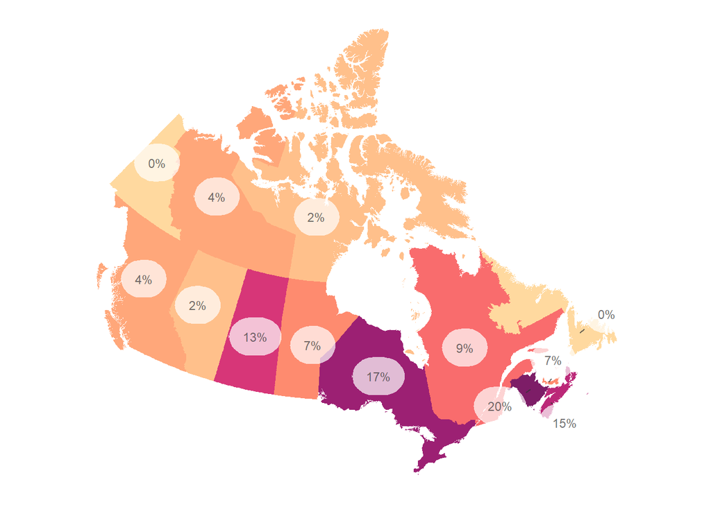

```r
ggplot() +
  geom_prov(alldata, fill = "values") + #changed the dataset to alldata
  crs_coord() +
  label_prov(alldata, label="perc") + #changed the dataset to alldata
  scale_fill_continuous_sequential(palette = "SunsetDark", na.value="grey90") +
  guides(fill = "none") +
  theme_map()
```

## Transforming your location data

The function `coord_transform()` allows you to transform location data (longitude/latitude) to the map’s coordinate system, which includes both projection and extent of the map. By default, this function uses the same projection as the `PROV` and `FSA` maps (epsg:4269). This allows us to easily transform any location data to be compatible for layering.

The `coord_transform()` function requires three pieces of information.

1. the name of the dataset
2. the name of the longitude variable in quotes
3. the name of the latitude variable in quotes

For this example we will be using the `canada.cities` dataset from the `maps` package. The dataset is then filtered for cities with population larger than 70,000 and then piped into the `coord_transform()` function. Here we can specify the column names for our longiture and latitude variables (note that the quotation marks are necessary here).

```r
library(maps)

cities <- canada.cities %>%
            filter(pop > 70000) %>%
  coord_transform("long", "lat")# this is to transform your points (quotation marks are necessary)
```

Once you’ve transformed your data using `coord_transform()` you can add it as a layer in your map using `geom_point()`. All you have to do is specify the name of the dataset and the x and y variables in the aesthetics. I’ve added a few extra parameters for size, color, transparency, and shape. You can also use `geom_jitter()` to avoid overlapping points. You can specify the parameters for width and height to achieve an appropriate distance between points.

### Map

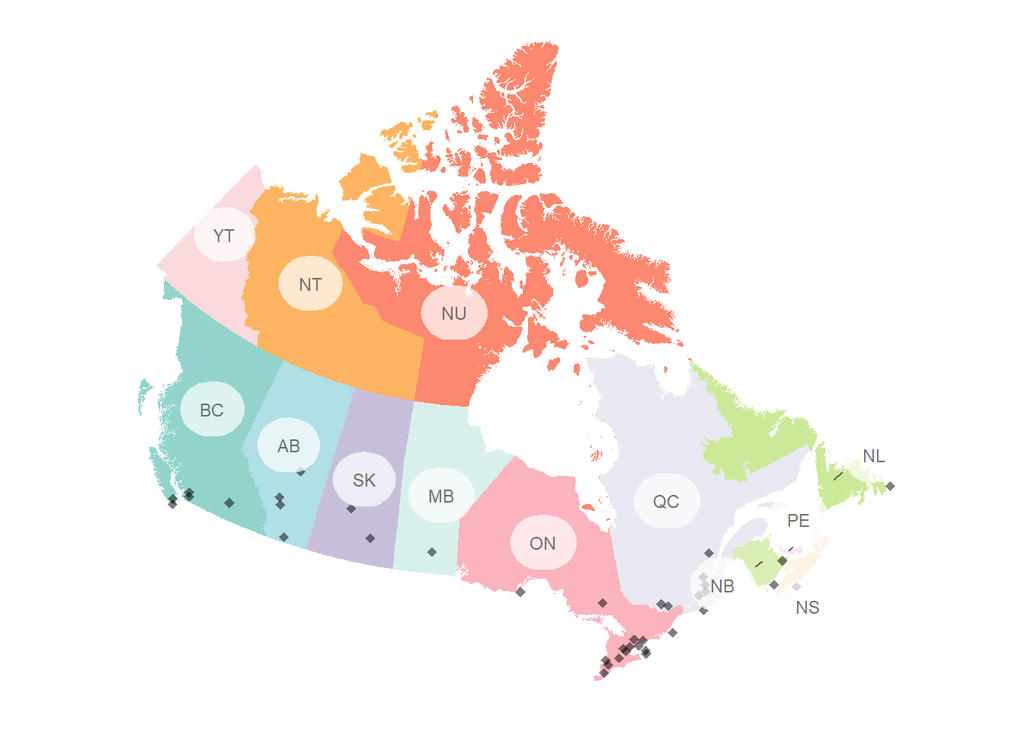

### Data

```r
head(cities)
```

```
##                        name country.etc    pop capital       long     lat
## 1             Abbotsford BC          BC 157795       0 -2162244.9 7125374
## 41                Barrie ON          ON 198492       0   957341.6 6155817
## 85             Brantford ON          ON  87972       0   935584.0 6009594
## 106              Calgary AB          AB 991432       0 -1536167.8 7087298
## 155 Chicoutimi-Jonquiere QC          QC 110582       0  1490065.3 6763119
## 230             Edmonton AB          AB 831979       2 -1408114.7 7335631
##     optional
## 1       TRUE
## 41      TRUE
## 85      TRUE
## 106     TRUE
## 155     TRUE
## 230     TRUE
```

### Code

```r
ggplot() +
  geom_prov() +
  crs_coord() +
  geom_jitter(data=cities, aes(x=long, y=lat), size = 2, color = "black", alpha=0.5, shape = 18, position = position_jitter(width = 70000, height = 70000)) + # adding points
  label_prov() +
  scale_fill_map("Kelly", 13) +
  guides(fill = "none") +
  theme_map()
```

## Point shape, size, color, and opacity

If you want to color your shapes based on another variable, you can do so by specifying color in the aesthetics of `geom_point()` or `geom_jitter()` and adding `scale_color_manual()`. Here I decided to change the shape, size, color, and alpha (transparency) all based on the column `type` which has three values.

### Map

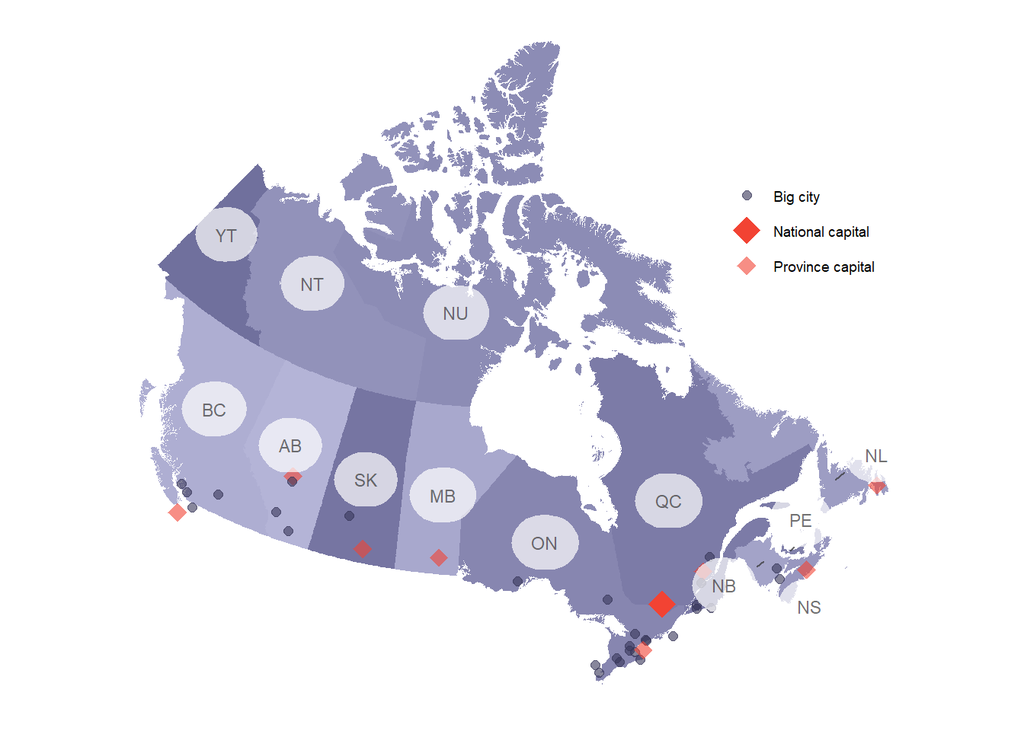

### Data

```r
cities <- canada.cities %>%
            filter(pop > 70000) %>%
  coord_transform("long", "lat") %>% # this is to transform your points (quotation marks are necessary)
  mutate(type = recode(capital,
                         "0" = "Big city",
                         "1" = "National capital",
                         "2" = "Province capital" )) # created the variable type for our shape, alpha, size, and color aesthetics
head(cities)
```

```
##                        name country.etc    pop capital       long     lat
## 1             Abbotsford BC          BC 157795       0 -2162244.9 7125374
## 41                Barrie ON          ON 198492       0   957341.6 6155817
## 85             Brantford ON          ON  87972       0   935584.0 6009594
## 106              Calgary AB          AB 991432       0 -1536167.8 7087298
## 155 Chicoutimi-Jonquiere QC          QC 110582       0  1490065.3 6763119
## 230             Edmonton AB          AB 831979       2 -1408114.7 7335631
##     optional             type
## 1       TRUE         Big city
## 41      TRUE         Big city
## 85      TRUE         Big city
## 106     TRUE         Big city
## 155     TRUE         Big city
## 230     TRUE Province capital
```

### Code

```r
ggplot() +
  geom_prov() + # province shapes
  crs_coord() +
  geom_jitter(data=cities, aes(x=long, y=lat, alpha=type, color=type, shape=type, size = type), position = position_jitter(width = 60000, height = 60000)) +
  scale_alpha_manual(values = c(0.6, 1, 0.6))+ # transparency for the type values
  scale_shape_manual(values=c(19, 18, 18))+  # shape for the type values
  scale_color_manual(values=c('#373659', '#F24333', '#F24333'))+  # color for the type values
  scale_size_manual(values=c(2, 6, 4))+  # size for the type values
  label_prov() + # province labels
  scale_fill_map("Viv", 36, rev=F) +
  guides(fill = "none") +
  theme_map() +
  theme(legend.position = c(0.75, 0.6),
        legend.title = element_blank())
```

## Mapping FSA data

The function `geom_fsa()` maps FSA data from StatCan. The default is to color based on each province. Similar to before you can merge your own data based on FSA columns to the `FSA` dataset. For now let’s just take a look at the default FSA map.

### FSA base layer

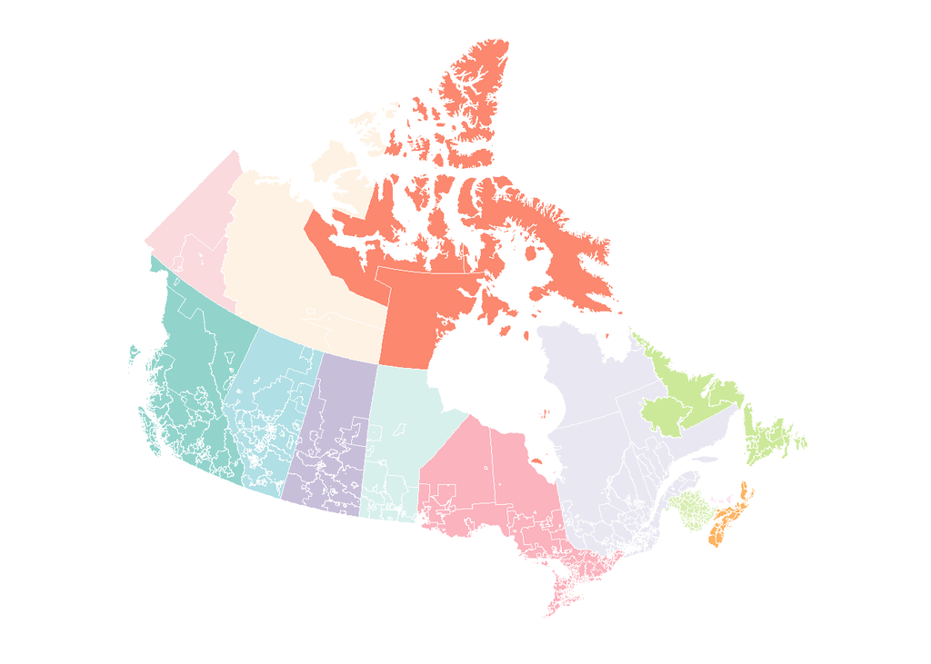

```r
ggplot() +
  geom_fsa() +
  crs_coord() +
  scale_fill_map("Kelly", 13) +
  guides(fill = "none") +
  theme_map()
```

### FSA with labels

Now let’s add some labels. Using the `text_prov()` function we will add labels in the center of each province. Similar to before, you can merge your own data with the `PROV` dataset to achieve different labels. For now we’ll start with adding the province codes which is the default.

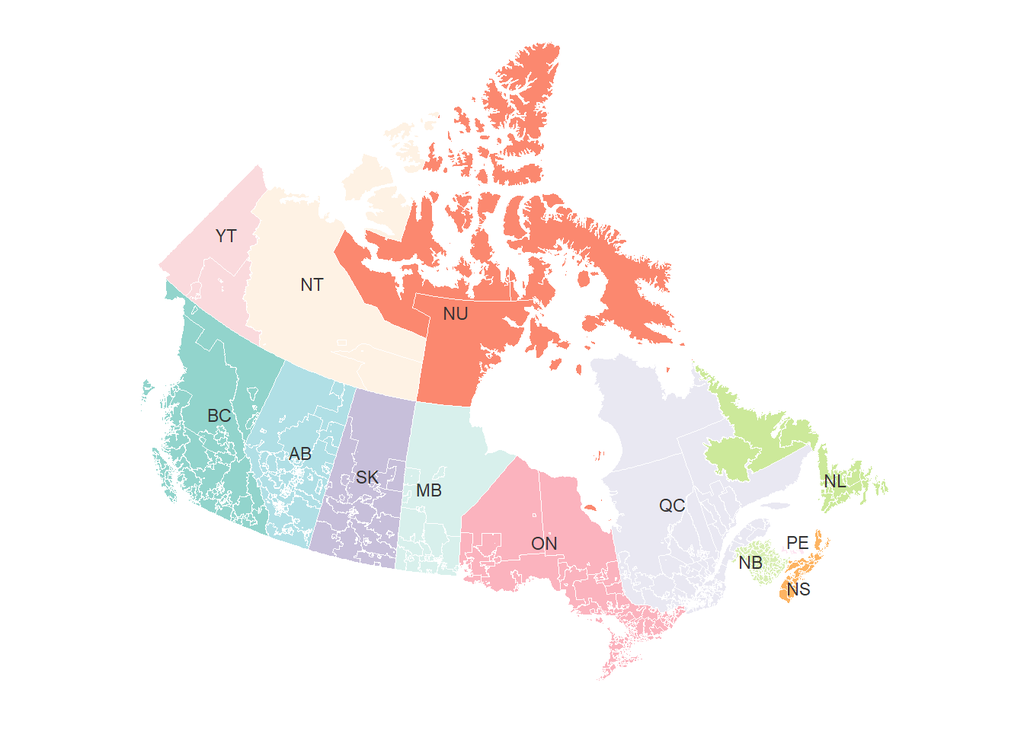

```r
ggplot() +
  geom_fsa() +
  crs_coord() +
  text_prov() + # adding labels from the PROV dataset (default is two digit codes)
  scale_fill_map("Kelly", 13) +
  guides(fill = "none") +
  theme_map()
```

### Adding your own data

Using a mini example dataset called `data` we can map the top 100 FSA’s based on population size. We do this by joining our dataset `data` with the `FSA` dataset from the `canadianmaps` package.

#### Map

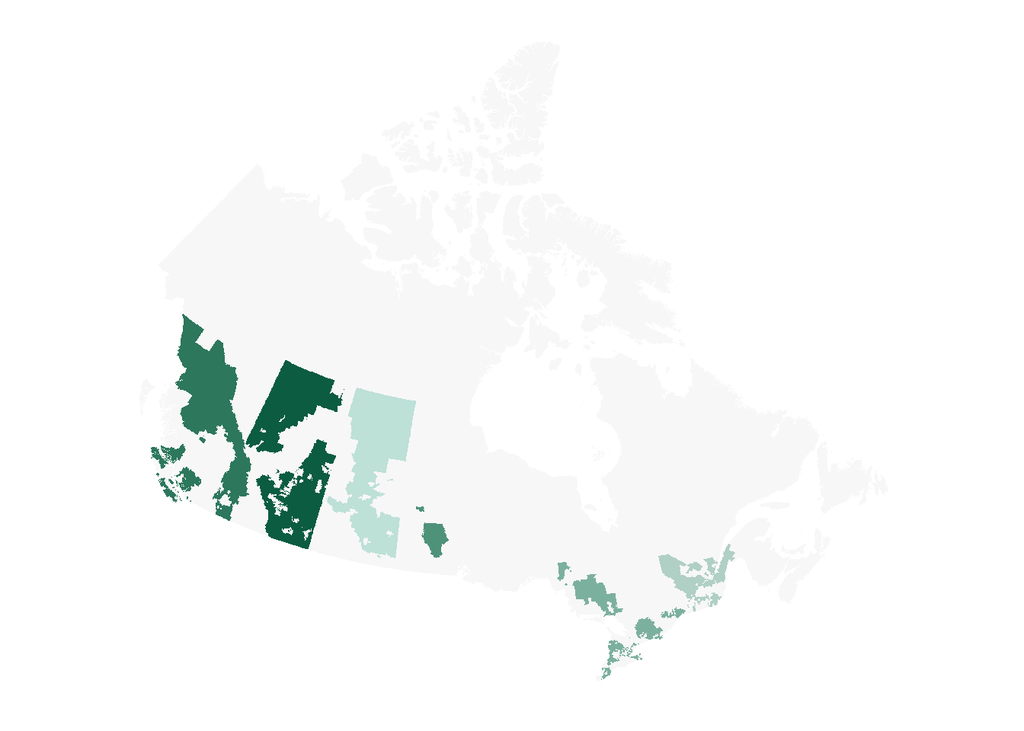

#### Data

```r
head(data)
```

```
##   fsa val
## 1 J0K   1
## 2 K0K   2
## 3 L5M   3
## 4 L9T   4
## 5 K0A   5
## 6 L4N   6
```

```r
myFSA <- FSA %>%
left_join(data, by = c("CFSAUID" = "fsa")) %>%
  mutate(PT = case_when(!is.na(val) ~ PRNAME,
                        TRUE ~ NA_character_))

head(myFSA)
```

```
## Simple feature collection with 6 features and 6 fields
## Geometry type: MULTIPOLYGON
## Dimension:     XY
## Bounding box:  xmin: -101.672 ymin: 49 xmax: -97.0942 ymax: 53.0132
## Geodetic CRS:  WGS 84
##   CFSAUID PRUID   PT   PRNAME rmapshaperid  val                       geometry
## 1     R0G    46 <NA> Manitoba            0 <NA> MULTIPOLYGON (((-97.4653 49...
## 2     R0H    46 <NA> Manitoba            1 <NA> MULTIPOLYGON (((-97.3899 50...
## 3     R0J    46 <NA> Manitoba            2 <NA> MULTIPOLYGON (((-100.2735 5...
## 4     R0K    46 <NA> Manitoba            3 <NA> MULTIPOLYGON (((-99.3172 50...
## 5     R0L    46 <NA> Manitoba            4 <NA> MULTIPOLYGON (((-100.0232 5...
## 6     R0M    46 <NA> Manitoba            5 <NA> MULTIPOLYGON (((-100.5307 5...
```

#### Code

```r
myFSA <- FSA %>%
left_join(data, by = c("CFSAUID" = "fsa")) %>%
  mutate(PT = case_when(!is.na(val) ~ PRNAME,
                        TRUE ~ NA_character_))

ggplot() +
  geom_fsa(myFSA, fill="PT", colour= NA) + #remove lines by specifying color = NA
  crs_coord() +
  scale_fill_map("Starbs", 8, na.value = "grey97") +
  guides(fill = "none") +
  theme_map()
```

## Mapping Regional data

The third dataset in the `canadianmaps` package is a Regional dataset called `REG`. This file was made using the provincial shapefile, meaning there are still 13 shapes however they are grouped by region. The functions `geom_reg()` and `label_reg()` are used to create these Regional maps.

Note: If you specify a `colour` in the `geom_reg()` function it will outline every Province (not Region). You can also change the `size` of the line, default is 0.1.

### Default Regions

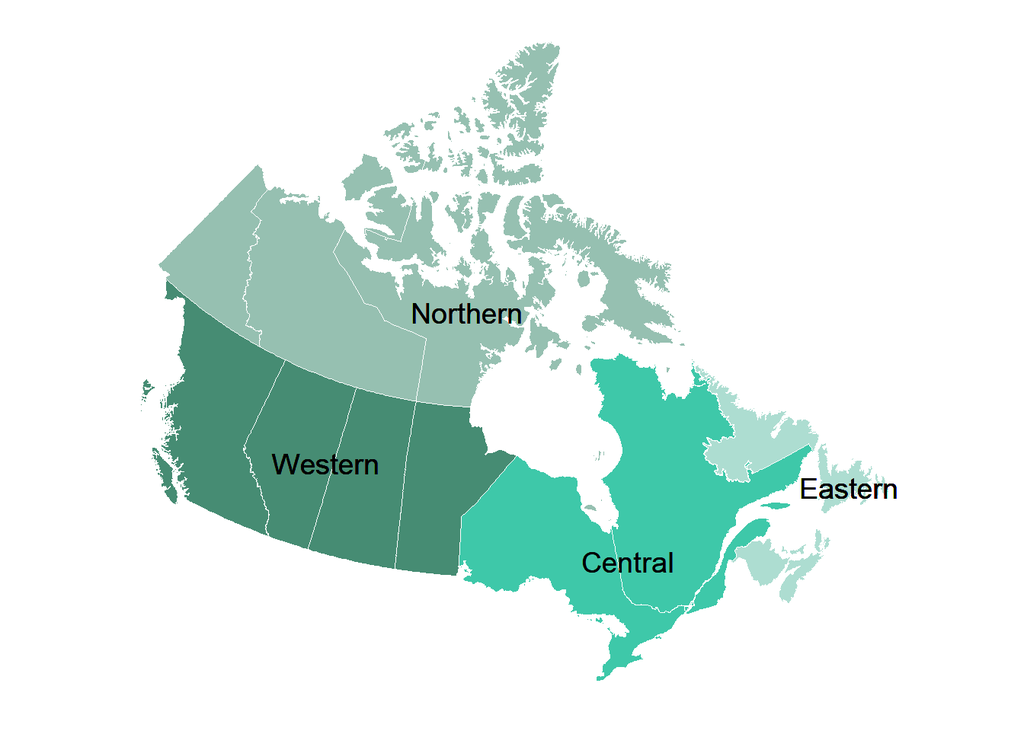

```r
ggplot() +
  geom_reg(colour="white") + # adding an outline colour (default is NA)
  crs_coord() +
  label_reg(size=5, colour = "black") +
  scale_fill_map("Starbs", 5, rev=T) +
  guides(fill = "none") +
  theme_map()
```

### Creating your own Regions

Using the `REG` dataset, you can create your own Regions by assigning Provinces/Territories a new value. Note that if you wish to add labels, you will need to choose points on the map yourself (https://www.latlong.net/) and transform them using `coord_transform()`. You could then use `geom_text()` from the `ggplot2` package to add your labels.

#### Map

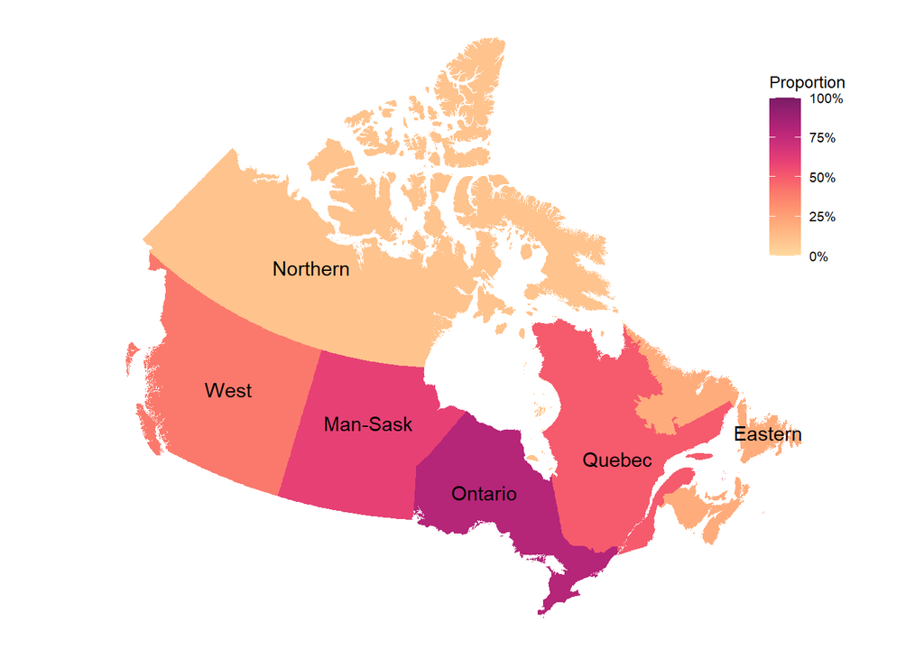

#### Code

```r
myreg <- REG %>%
  mutate(region2 = case_when(PT %in% c("BC", "AB") ~ "West",
                             PT %in% c("MB", "SK") ~ "Man-Sask",
                             PT %in% c("ON") ~ "Ontario",
                             PT %in% c("QC") ~ "Quebec",
                             TRUE ~ region)) %>%
  mutate(Proportion = case_when(region2 == "West" ~ 0.4,
                                region2 == "Man-Sask" ~ 0.6,
                                region2 == "Ontario" ~ 0.8,
                                region2 == "Quebec" ~ 0.5,
                                region2 == "Eastern" ~ 0.2,
                                region2 == "Northern" ~ 0.1
                                ))

# In order to transform the latitude/longitude points, you need to convert the complex geometry dataset to a regular dataset/tibble
myreg_labels <- myreg %>%
  as_tibble()%>%
  dplyr::select(region2, Proportion)%>%
  mutate(latitude = case_when(region2 == "West" ~ 54.897934,
                                region2 == "Man-Sask" ~ 55.549611,
                                region2 == "Ontario" ~ 50.926410,
                                region2 == "Quebec" ~ 51.531814,
                                region2 == "Eastern" ~ 48.599317,
                                region2 == "Northern" ~ 65.397728
                                ),
         longitude = case_when(region2 == "West" ~ -119.777942,
                                region2 == "Man-Sask" ~ -101.572435,
                                region2 == "Ontario" ~ -87.324647,
                                region2 == "Quebec" ~ -71.654470,
                                region2 == "Eastern" ~ -55.399047,
                                region2 == "Northern" ~ -115.797786
                                )) %>%
  coord_transform("longitude", "latitude") %>%
  unique()


ggplot() +
  geom_reg(data=myreg, fill="Proportion") +
  crs_coord() +
  geom_text(data=myreg_labels, aes(x=longitude, y=latitude, label=region2))+
  scale_fill_continuous_sequential(limits = c(0,1),palette = "SunsetDark", na.value="grey90", label = scales::percent) +
  theme_map() +
  theme(legend.position = c(0.9, 0.6)) +
   labs(fill="Proportion")
```

## Graphing

The functions `scale_fill_map()` and `scale_color_map()` can also be used with other plot types in `ggplot2`.

### Graph

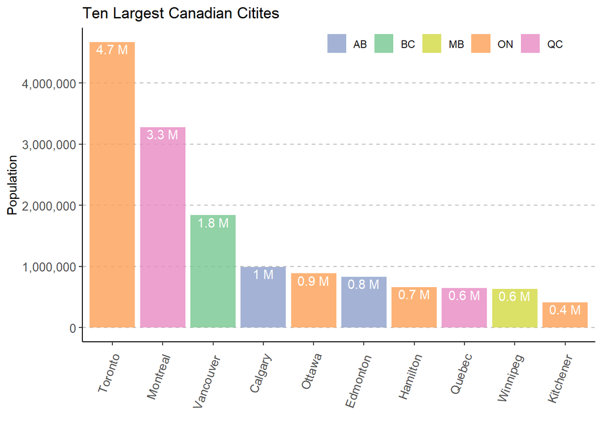

### Code

```r
library(maps)

canada.cities %>%
  filter(country.etc != "Canada")%>%
  mutate(name = str_to_sentence(word(name)))%>%
  arrange(desc(pop))%>%
  slice_max(order_by = pop, n = 10)%>%
  mutate(label = str_glue("{round(pop/1000000, 1)} M"))%>%

  ggplot() +
    aes(x=reorder(name, desc(pop)), y = pop, fill=country.etc)+
    geom_col(alpha = 0.8)+
    geom_text(aes(label=label), vjust = 1.2, color = "white")+
    scale_fill_map("Bright", 5) +
  scale_y_continuous(labels = scales::comma)+
    theme_wallis() +
  ggtitle("Ten Largest Canadian Citites") +
    xlab("")+
    ylab("Population")+
    labs(fill = "")+
    theme(legend.position = c(0.7, 0.95),
          legend.direction = "horizontal",
          legend.background = element_rect(fill=NA),
          axis.text.x = element_text(angle = 70, hjust = 1.1))
```

## Thank you!!

Huge thank you to the entire CNISP team for your contributions to the package and continued support! Special thanks to Linda Pelude, Wallis Rudnick, Anada Silva, Vivienne Steele, Kelly Choi, Robyn Mitchell, Jessica Bartoszko, Diane Lee and William Zhang.